# Data Exploration

This is distributed under a https://creativecommons.org/licenses/by/4.0/.

# Getting data into R

## Ways to get data into R

In order to use your data in R, you must import it and turn it into an R *object*. There are many ways to get data into R.

- **Manually**: You can manually create it as we did at the end of last session. To create a data.frame, use the `data.frame()` and specify your variables.
- **Import it from a file** Below is a very incomplete list
- Text: TXT (`readLines()` function)
- Tabular data: CSV, TSV (`read.table()` function or `readr` package)
- Excel: XLSX (`xlsx` package)
- Google sheets: (`googlesheets` package)
- Statistics program: SPSS, SAS (`haven` package)
- Databases: MySQL (`RMySQL` package)
- **Gather it from the web**: You can connect to webpages, servers, or APIs directly from within R, or you can create a data scraped from HTML webpages using the `rvest` package.
- For example, connect to the Twitter API with the [`twitteR`](https://sites.google.com/site/miningtwitter/questions/talking-about/wordclouds/wordcloud1) package, or Altmetrics data with [`rAltmetric`](https://cran.r-project.org/web/packages/rAltmetric/vignettes/intro-to-altmetric.html), or World Bank’s World Development Indicators with [`WDI`](https://cran.r-project.org/web/packages/WDI/WDI.pdf).

## `readr`

R has some base functions for reading a local data file into your R session–namely `read.table()` and `read.csv()`, but these have some idiosyncrasies that were improved upon in the `readr` package, which is installed and loaded with `tidyverse`. You can either load `tidyverse`, which will automatically load `readr`, or you can load `readr` individually.

```r
library(tidyverse)

# or

library(readr)
```

For this session, we will be reading a CSV from a web connection rather than saving the data to our computer and loading it into R. However, to do that, see the below section on Loading data from a local file.

To get our sample data into our R session, we will use the `read_csv()` function and connect to a CSV saved on my GitHub using the `url()` function.

```r
books_url <- url("https://raw.githubusercontent.com/ciakovx/ciakovx.github.io/master/fsci2020/data/books.csv")
books <- readr::read_csv(books_url)
books
```

[output not shown]

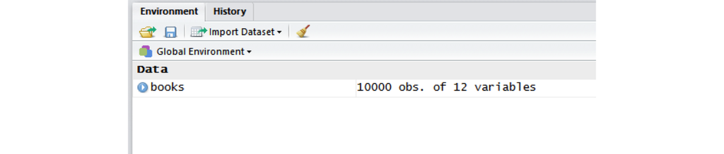

## Loading data from a local file

### Set your working directory

The **working directory** is the location on your computer R will use for reading and writing files. Use `getwd()` to print your current working directory to the console. Use `setwd()` to set your working directory. There are two important points to make here;

- On Windows computers, directories in file paths are separated with a backslash `\`. However, in R, you must use a forward slash `/`. I usually copy and paste from the Windows Explorer (or Mac Finder) window directly into R and use the find/replace (Ctrl/Cmd + F).
- The directory must be in quotation marks.

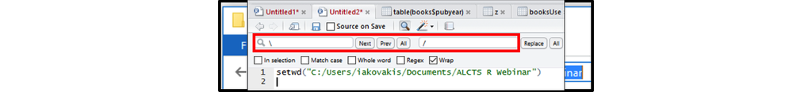

```r
# set working directory using a forward slash /
setwd("C:/Users/iakovakis/Desktop/fsci_AM4")

# print working directory to the console
getwd()
```

```
## [1] "C:/Users/iakovakis/Desktop/fsci_AM4"
```

**TRY IT YOURSELF**

```r
# set your working directory to wherever you saved the data files for this webinar
setwd("C:/Wherever you saved the files/fsci_AM4_files")

# read the books file into your R environment and assign it to books
# not all of these arguments are necessary, but I'm putting them here for example purposes
books <- readr::read_csv("./data/raw/books.csv")
```

## Import Dataset tool in R Studio

R Studio has a data importing wizard in the Environment Pane (upper right): **Import Dataset:**

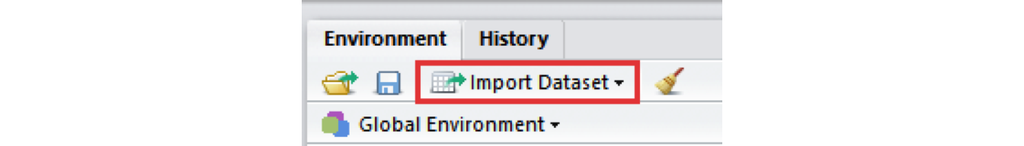

I never use this. I type the `read_csv()` function directly in my script files, as it gives me more control over the arguments and I am not limited to the choices R Studio gives me.